# Exploratory Data Analysis on Hospital Billing Data

# Preliminary cleaning

Manipulations:

- Remove rows with MRN only (NA in other columns).
- Mutate `pt_deceased` to a logical variable.
- Unify “unknown” categories in `pt_race`.
- Unify “unknown” categories in `pt_ethnicity`.

After cleaning, `skim()` would reveal the general structure of the remaining data set:

Data summary

| Name | data |
| --- | --- |
| Number of rows | 47634 |
| Number of columns | 39 |
| _______________________ |  |
| Column type frequency: |  |
| character | 33 |
| logical | 1 |
| numeric | 1 |
| POSIXct | 4 |
| ________________________ |  |
| Group variables | None |

**Variable type: character**

| skim_variable | n_missing | complete_rate | min | max | empty | n_unique | whitespace |
| --- | --- | --- | --- | --- | --- | --- | --- |
| dept_name | 0 | 1.00 | 6 | 39 | 0 | 62 | 0 |
| div_name | 0 | 1.00 | 9 | 37 | 0 | 152 | 0 |
| bar_name | 0 | 1.00 | 4 | 47 | 0 | 355 | 0 |
| loc_name | 0 | 1.00 | 5 | 38 | 0 | 95 | 0 |
| loc_cat_2_name | 0 | 1.00 | 2 | 18 | 0 | 7 | 0 |
| pt_sex | 0 | 1.00 | 4 | 6 | 0 | 2 | 0 |
| pt_race | 0 | 1.00 | 5 | 20 | 0 | 7 | 0 |
| pt_ethnicity | 0 | 1.00 | 12 | 23 | 0 | 3 | 0 |
| pt_state | 0 | 1.00 | 2 | 2 | 0 | 22 | 0 |
| bill_prov_name | 0 | 1.00 | 11 | 30 | 0 | 1230 | 0 |
| cpt_code | 0 | 1.00 | 4 | 6 | 0 | 1370 | 0 |
| cpt_desc | 0 | 1.00 | 7 | 79 | 0 | 1370 | 0 |
| pos | 0 | 1.00 | 2 | 2 | 0 | 10 | 0 |
| dx1_code | 4 | 1.00 | 2 | 8 | 0 | 2668 | 0 |
| dx1_desc | 4 | 1.00 | 5 | 166 | 0 | 2668 | 0 |
| dx2_code | 24545 | 0.48 | 2 | 8 | 0 | 2159 | 0 |
| dx2_desc | 24545 | 0.48 | 5 | 164 | 0 | 2159 | 0 |
| dx3_code | 32734 | 0.31 | 2 | 8 | 0 | 1593 | 0 |
| dx3_desc | 32734 | 0.31 | 5 | 164 | 0 | 1593 | 0 |
| dx4_code | 37201 | 0.22 | 2 | 8 | 0 | 1221 | 0 |
| dx4_desc | 37201 | 0.22 | 5 | 164 | 0 | 1221 | 0 |
| dx5_code | 40486 | 0.15 | 3 | 8 | 0 | 941 | 0 |
| dx5_desc | 40486 | 0.15 | 8 | 164 | 0 | 941 | 0 |
| dx6_code | 42852 | 0.10 | 3 | 8 | 0 | 650 | 0 |
| dx6_desc | 42852 | 0.10 | 8 | 164 | 0 | 650 | 0 |
| dx7_code | 44386 | 0.07 | 3 | 8 | 0 | 450 | 0 |
| dx7_desc | 44386 | 0.07 | 8 | 164 | 0 | 450 | 0 |
| dx8_code | 45632 | 0.04 | 3 | 8 | 0 | 268 | 0 |
| dx8_desc | 45632 | 0.04 | 10 | 164 | 0 | 268 | 0 |
| dx9_code | 47634 | 0.00 | NA | NA | 0 | 0 | 0 |
| dx9_desc | 47634 | 0.00 | NA | NA | 0 | 0 | 0 |
| dx10_code | 47634 | 0.00 | NA | NA | 0 | 0 | 0 |
| dx10_desc | 47634 | 0.00 | NA | NA | 0 | 0 | 0 |

**Variable type: logical**

| skim_variable | n_missing | complete_rate | mean | count |
| --- | --- | --- | --- | --- |
| pt_deceased | 0 | 1 | 0.16 | FAL: 40138, TRU: 7496 |

**Variable type: numeric**

| skim_variable | n_missing | complete_rate | mean | sd | p0 | p25 | p50 | p75 | p100 | hist |
| --- | --- | --- | --- | --- | --- | --- | --- | --- | --- | --- |
| new_mrn | 0 | 1 | 40165947 | 19495211 | 6356944 | 18068240 | 51633408 | 57508824 | 64858592 | ▅▃▁▃▇ |

**Variable type: POSIXct**

| skim_variable | n_missing | complete_rate | min | max | median | n_unique |
| --- | --- | --- | --- | --- | --- | --- |
| new_dob | 4295 | 0.91 | 1964-10-03 | 2020-05-11 | 2005-03-28 | 447 |
| new_srvc_date | 4295 | 0.91 | 2010-06-06 | 2022-02-09 | 2014-11-29 | 3953 |
| new_visit_adm_dt_time | 4294 | 0.91 | 2010-05-13 | 2022-02-10 | 2014-11-16 | 3117 |
| new_visit_disch_time | 4295 | 0.91 | 2010-06-06 | 2022-02-10 | 2014-12-05 | 3144 |

So basically, we have:

- 47634 valid records of hospital billings. Each record consists of 39 columns.
- All character variables excluding diagnoses are complete, without missing values.
  - Note that some categorical data are marked as “unknown”.

Starting from here, we will group data by unique patient as some patients have multiple billing records.

# EDA

One thing to notice here is that the medical record number (MRN) should be unique for each patient, but there seems to be a discrepancy in Date of Birth:

```
## # A tibble: 933 × 6
##     new_mrn new_dob             pt_sex pt_race pt_deceased pt_ethnicity
##       <dbl> <dttm>              <chr>  <chr>   <lgl>       <chr>
##  1 51587384 2005-04-07 00:00:00 female WHITE   FALSE       NON HISPANIC
##  2 51587384 2008-02-08 00:00:00 female WHITE   FALSE       NON HISPANIC
##  3 51587384 2003-09-12 00:00:00 female WHITE   FALSE       NON HISPANIC
##  4 51587384 2000-11-03 00:00:00 female WHITE   FALSE       NON HISPANIC
##  5 51587384 2001-05-17 00:00:00 female WHITE   FALSE       NON HISPANIC
##  6 51587384 1999-05-06 00:00:00 female WHITE   FALSE       NON HISPANIC
##  7 51587384 1999-05-06 00:00:00 female WHITE   FALSE       NON HISPANIC
##  8 51587384 2007-11-20 00:00:00 female WHITE   FALSE       NON HISPANIC
##  9 51587384 2005-03-28 00:00:00 female WHITE   FALSE       NON HISPANIC
## 10 51587384 2005-03-28 00:00:00 female WHITE   FALSE       NON HISPANIC
## # … with 923 more rows
```

## Patients

- Add a manual `ID` to distinguish each patient.

> If we randomly assign a `DOB` to the records under the same `MRN`, we could’ve ended up with some ages < 0 by the time of the visit.
- Calculate the age by the time of the service.

### Age distribution

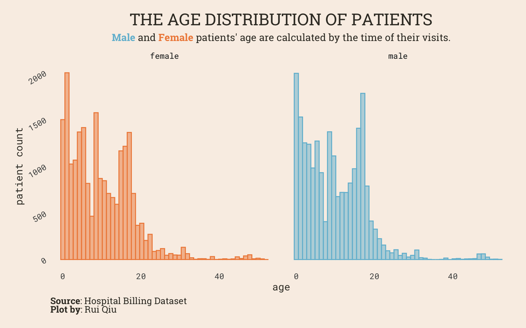

### Geolocation

[figure not shown]

**Click here for better resolution and scale.**

### Time of visiting by major states

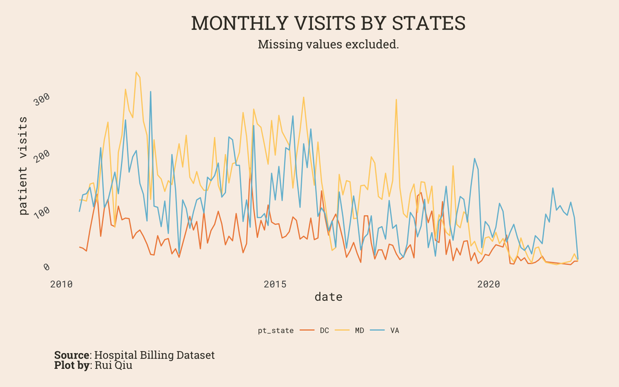

## Diagnosis

Due to limited prior medical knowledge, I only managed to combine multiple diagnoses of the same patient together to see if some keywords are predominant in the large picture.

> A better approach would be using some pre-defined medical term dictionary to match the patterns of diagnoses.

The resulted data frame looks like this:

| ID | dx |
| --- | --- |
| 1525 | YOUNG PRIMIGRAVIDA OBESITY COMPLICATING PREGNANCY, CHILDBIRTH, OR THE PUERPERIUM, ANTEPARTUM CONDITION OR COMPLICATION GROUP B STREPTOCOCCUSNA |
| 1780 | WHEEZING SYMP RESP SYS COUGH ASTHMA W/O STATUS UNSP ORGAN OR TISSUE REPLACED BY TRANSPLANT; BONE MARROW OTH/UNSP ABN HIST/IMMU NONSPEC FINDNA |
| 1780 | WHEEZING ASTHMA W/O STATUS UNSPNA |
| 1719 | WHEEZING ASTHMA W/O STATUS UNSPNA |
| 1764 | WHEEZINGNA |
| 1746 | WHEEZING~R06.2 COUGH~R05 UNSPECIFIED ASTHMA, UNCOMPLICATED~J45.909 ANXIETY DISORDER, UNSPECIFIED~F41.9 BONE MARROW TRANSPLANT STATUS~Z94.81NA |
| 13503 | WHEEZING~R06.2NA |
| 11382 | XEROSIS CUTIS~L85.3 SEBORRHEIC DERMATITIS, UNSPECIFIED~L21.9NA |
| 5783 | ZOSTER WITH OTHER COMPLICATIONS~B02.8 MALIGNANT NEOPLASM OF BRAIN, UNSPECIFIED~C71.9NA |
| 5783 | ZOSTER WITH OTHER COMPLICATIONS~B02.8 MALIGNANT NEOPLASM OF BRAIN, UNSPECIFIED~C71.9 IMMUNODEFICIENCY, UNSPECIFIED~D84.9NA |

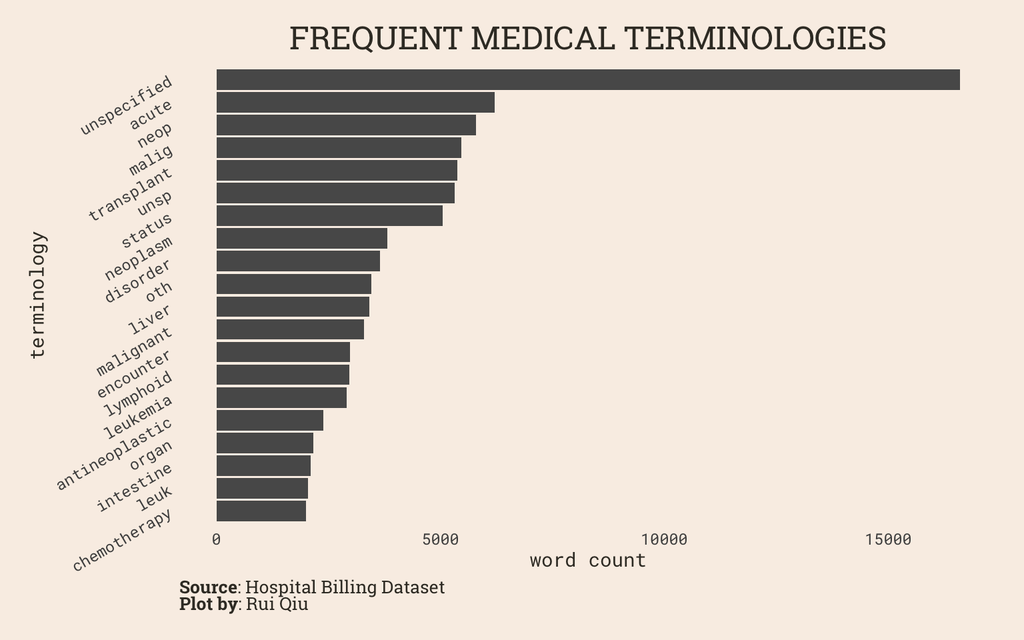

# Dashboard

It is accessible at [this link](https://rexarski.shinyapps.io/hospital-billing/)